# ggplot2_practice.rmd

Wenshu chen

2024-09-29

### Introduction

This is the final assignment for [ggplot2 course](https://www.coursera.org/learn/jhu-data-visualization-r) taught by Dr. Collin Paschall from Johns Hopkins University.

The assignment asks to make four original visualizations with required customization (color, theme, adding text, facet_wrap, etc.) using ggplot2.  
Two datasets are provided, but students are free to use any subset of data and have to process the data as needed themselves.

Original data sources:  
[CCES data](https://dataverse.harvard.edu/dataset.xhtml?persistentId=doi:10.7910/DVN/WOT7O8) from the Center for Effective Lawmaking;  
[CEL data](https://thelawmakers.org/data-download) from the Center for Effective Lawmaking.

Note that sample data used for the exercise have been modified by Dr. Paschall for teaching purpose.

The following codes try to provide some meaningful information with data processing and customization. This is a course assignment though, not a serious data analysis.

#### Setup and data

```r
knitr::opts_chunk$set(echo = TRUE)

library(tidyverse, quietly = TRUE)
library(ggplot2)
library(ggthemes, quietly = TRUE)

cces <- drop_na(read.csv("cces_sample_coursera.csv"))
cel <- drop_na(read.csv("cel_volden_wiseman_coursera.csv"))
```

#### Box plot

We look at legislative effective score for congress members by party over five congresses.  
Members with highest score were marked.

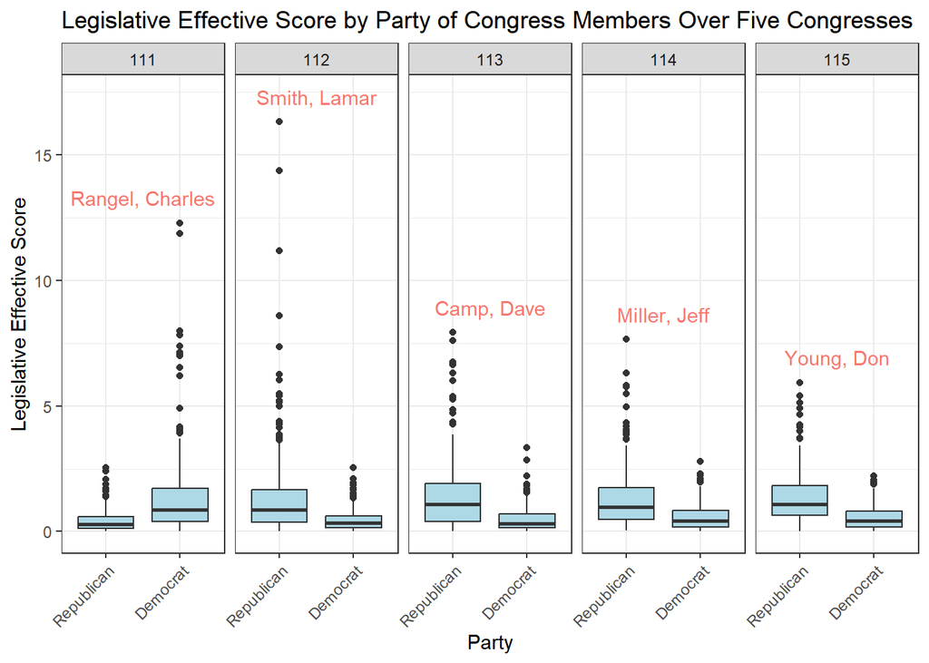

```r
c5 = cel[cel$congress %in% c(111, 112, 113, 114, 115), ]
les_max = sapply(unique(cel$congress), function(x) max(cel[cel$congress==x,]$les))
les_max_last5 = tail(sapply(les_max, function(x) cel[cel$les == x, ]$thomas_name), 5)
label_df = data.frame(label = c(les_max_last5),
                      les = tail(les_max, 5))
label_df$congress = 111:115
ggplot(c5, aes(x = as.factor(dem), y = les)) +
    geom_boxplot(fill = "lightblue") +
    facet_wrap(~factor(congress), nrow=1) +
    scale_x_discrete(label = c("0" = "Republican", "1" = "Democrat")) +
    theme_bw() +
    labs(x = "Party", y = "Legislative Effective Score",
         title = "Legislative Effective Score by Party of Congress Members Over Five Congresses") +
    geom_text(data = label_df,
              mapping = aes(x = 1.5, y = les+1,
              label = label, color = "#FF9999")) +
    theme(axis.text.x = element_text(angle=45, hjust = 1),
          legend.position = "none")
```

#### Stacked bar plot

We look at President Trump’s approval with respect to people’s gender and education.

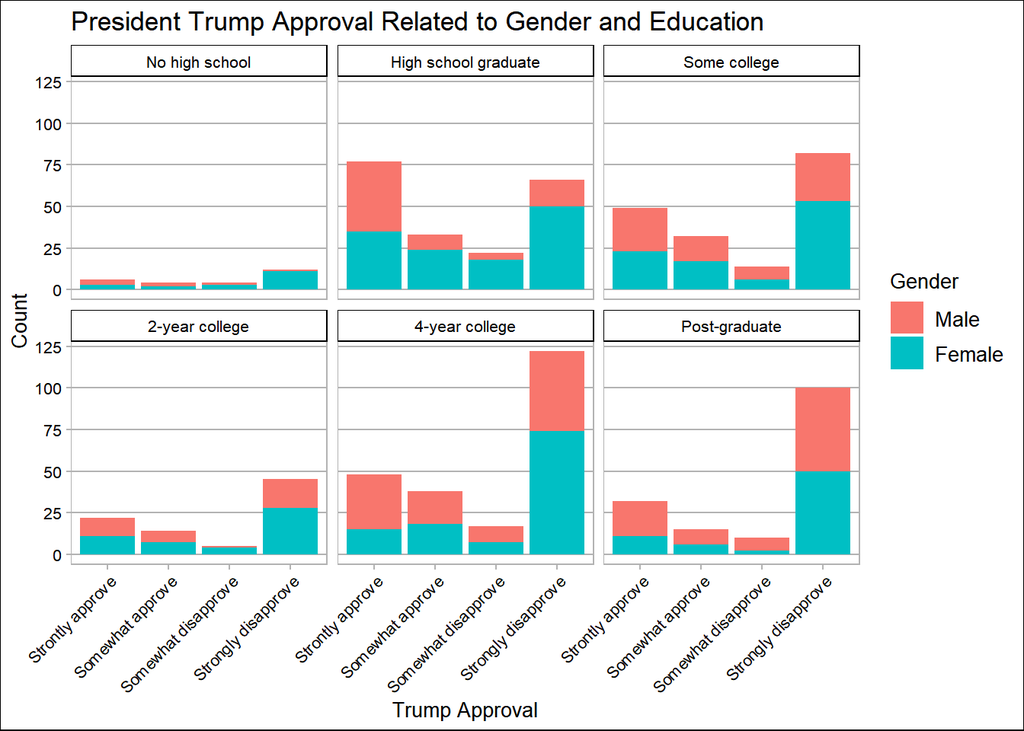

```r
ggplot(cces, aes(x = CC18_308a, fill = as.factor(gender))) +
    geom_bar() +
    facet_wrap(~educ, labeller = as_labeller(c("1" =  "No high school", "2" = "High school graduate",
                                               "3" = "Some college", "4" = "2-year college",
                                               "5" = "4-year college", "6" = "Post-graduate"))) +
    labs(x = "Trump Approval", y = "Count",
         title = "President Trump Approval Related to Gender and Education") +
    theme_calc() +
    scale_x_discrete(limits = c("1"="Strontly approve", "2"="Somewhat approve",
                                "3"="Somewhat disapprove", "4"="Strongly disapprove"),) +
    scale_fill_discrete(name = "Gender",
                        labels = c("1" = "Male", "2" = "Female")) +
    theme(axis.text.x = element_text(angle=45, hjust = 1))
```

#### Line plot

We look at bill passed per congress member broken down by gender from congress 93 - 115.  
Bill passed (all_pass) was scaled by number of respective gender members to obtain per member average.

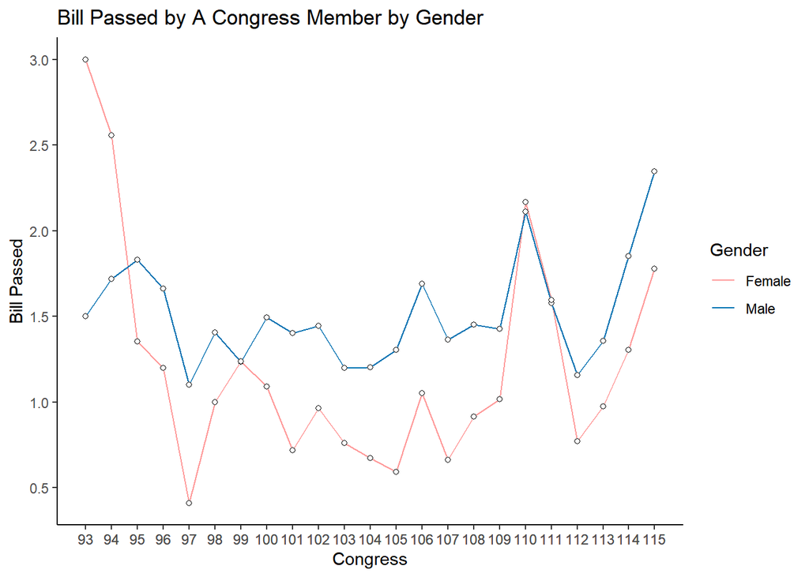

```r
pass_gender = aggregate(cel$all_pass, list(cel$congress, cel$female), sum)
colnames(pass_gender) = c("Congress", "Gender", "Bill_Passed")
pass_gender$Gender = ifelse(pass_gender$Gender==0, "Male", "Female")
mem_count = aggregate(as.character(cel$female), list(cel$congress, cel$female), length)
pass_gender$mem_count = mem_count$x
pass_gender$Pass_scaled = pass_gender$Bill_Passed/pass_gender$mem_count

ggplot(pass_gender, aes(x = Congress, y = Pass_scaled, group = c(Gender))) +
    geom_line(aes(color = Gender)) +
    geom_point(shape = 21, fill = "white") +
    labs(y = "Bill Passed",
         title = "Bill Passed by A Congress Member by Gender") +
    theme_classic() +
    scale_color_manual(values = c("#FF9999", "#0072B2")) +
    scale_x_continuous(labels = as.character(pass_gender$Congress), breaks = pass_gender$Congress) +
    scale_y_continuous(breaks = seq(0, 3, 0.5))
```

#### Scatter plot

We look at bills passed for congress members by seniority (terms served) in congress 115. Notable members were marked.

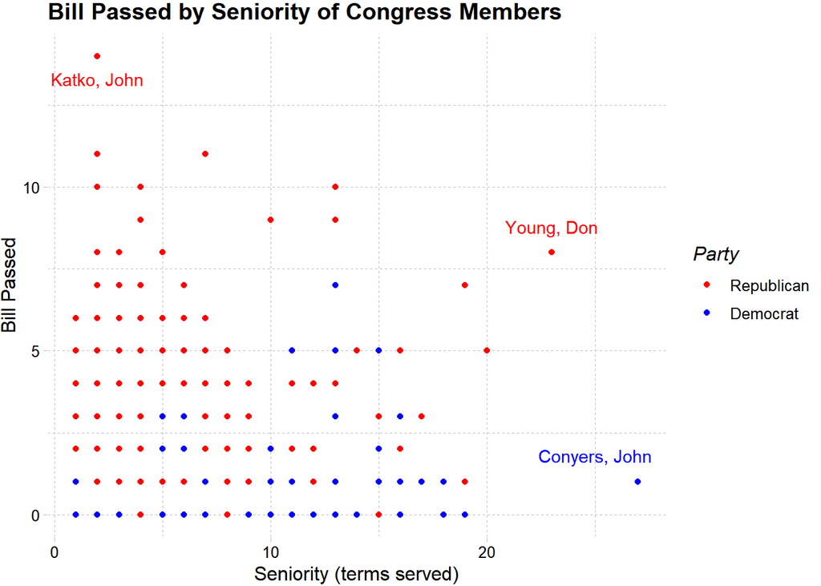

```r
cel115 = cel[cel$congress==115,]
longest_repub = cel115[cel115$dem==0 & cel115$seniority > 20,]$thomas_name
short_high_repub = cel115[cel115$dem==0 & cel115$all_pass > 13,]$thomas_name
longest_dem = cel115[cel115$dem==1 & cel115$seniority > 20,]$thomas_name

ggplot(cel115, aes(x=seniority, y=all_pass, color = factor(dem))) +
    geom_point() +
    theme_pander() +
    labs(x = "Seniority (terms served)", y = "Bill Passed",
         title = "Bill Passed by Seniority of Congress Members") +
    scale_color_manual(values = c("red", "blue"),
                       name = "Party",
                       labels = c("0" = "Republican", "1" = "Democrat")) +
    annotate("text", x = 23, y = 8.8, label = longest_repub, color = "red") +
    annotate("text", x = 2, y = 13.3, label = short_high_repub, color = "red") +
    annotate("text", x = 25, y = 1.8, label = longest_dem, color = "blue")
```